# Анализ мобильного приложения, который продаёт продукты питания.

# A/В тестирование

Необходимо разобраться, как ведут себя пользователи мобильного приложения. Изучить воронку продаж. Узнайть, как пользователи доходят до покупки. Сколько пользователей доходит до покупки, а сколько — «застревает» на предыдущих шагах? На каких именно? После этого исследовать результаты A/B-эксперимента. Дизайнеры захотели поменять шрифты во всём приложении, а менеджеры испугались, что пользователям будет непривычно. Договорились принять решение по результатам A/B-теста. Для него пользователей разбили на 3 группы: 2 контрольные со старыми шрифтами и одну экспериментальную — с новыми. Нужно выяснить, какой шрифт лучше.

- Шаг 1. Общая информация
- Шаг 2. Предобработка данных
- Шаг 3. Изучение и проверка данных
- Шаг 4. Анализ воронки событий
- Шаг 5. Анализ результатов эксперимента
- Шаг 6. Вывод

## Шаг 1. Общая информация

```python
import pandas as pd
import seaborn as sns
import matplotlib.pyplot as plt
import copy
```

```python
df = pd.read_csv('/datasets/logs_exp.csv', sep='\t', decimal=',')
```

```python
df.head()
```

|  | EventName | DeviceIDHash | EventTimestamp | ExpId |
| --- | --- | --- | --- | --- |
| 0 | MainScreenAppear | 4575588528974610257 | 1564029816 | 246 |
| 1 | MainScreenAppear | 7416695313311560658 | 1564053102 | 246 |
| 2 | PaymentScreenSuccessful | 3518123091307005509 | 1564054127 | 248 |
| 3 | CartScreenAppear | 3518123091307005509 | 1564054127 | 248 |
| 4 | PaymentScreenSuccessful | 6217807653094995999 | 1564055322 | 248 |

**Описание данных:**

```
EventName — название события;
DeviceIDHash — уникальный идентификатор пользователя;
EventTimestamp — время события;
ExpId — номер эксперимента: 246 и 247 — контрольные группы, а 248 — экспериментальная.
```

### Шаг 2. Подготовка данных

**Заменим названия столбцов на более удобные**

```python
df.rename(columns={'EventName': 'event', 'DeviceIDHash': 'user_id', 'EventTimestamp': 'event_time', 'ExpId':'group'}, inplace=True)
df.head()
```

|  | event | user_id | event_time | group |
| --- | --- | --- | --- | --- |
| 0 | MainScreenAppear | 4575588528974610257 | 1564029816 | 246 |
| 1 | MainScreenAppear | 7416695313311560658 | 1564053102 | 246 |
| 2 | PaymentScreenSuccessful | 3518123091307005509 | 1564054127 | 248 |
| 3 | CartScreenAppear | 3518123091307005509 | 1564054127 | 248 |
| 4 | PaymentScreenSuccessful | 6217807653094995999 | 1564055322 | 248 |

```python
df.info()
```

```
<class 'pandas.core.frame.DataFrame'>
RangeIndex: 244126 entries, 0 to 244125
Data columns (total 4 columns):
event         244126 non-null object
user_id       244126 non-null int64
event_time    244126 non-null int64
group         244126 non-null int64
dtypes: int64(3), object(1)
memory usage: 7.5+ MB
```

```
В таблице 244 126 строк, пропущенные значения отсутствуют. Типы данных корректные
```

**Добавим столбец даты и времени, а также отдельный столбец дат**

```python
df.event_time = pd.to_datetime(df.event_time, unit = 's')
df['date'] = df.event_time.dt.date
df.head()
```

|  | event | user_id | event_time | group | date |
| --- | --- | --- | --- | --- | --- |
| 0 | MainScreenAppear | 4575588528974610257 | 2019-07-25 04:43:36 | 246 | 2019-07-25 |
| 1 | MainScreenAppear | 7416695313311560658 | 2019-07-25 11:11:42 | 246 | 2019-07-25 |
| 2 | PaymentScreenSuccessful | 3518123091307005509 | 2019-07-25 11:28:47 | 248 | 2019-07-25 |
| 3 | CartScreenAppear | 3518123091307005509 | 2019-07-25 11:28:47 | 248 | 2019-07-25 |
| 4 | PaymentScreenSuccessful | 6217807653094995999 | 2019-07-25 11:48:42 | 248 | 2019-07-25 |

**Поиск дупликатов**

```python
df[df.duplicated(keep=False) == True]
```

|  | event | user_id | event_time | group | date |
| --- | --- | --- | --- | --- | --- |
| 452 | MainScreenAppear | 5613408041324010552 | 2019-07-30 08:19:44 | 248 | 2019-07-30 |
| 453 | MainScreenAppear | 5613408041324010552 | 2019-07-30 08:19:44 | 248 | 2019-07-30 |
| 2348 | CartScreenAppear | 1694940645335807244 | 2019-07-31 21:51:39 | 248 | 2019-07-31 |
| 2350 | CartScreenAppear | 1694940645335807244 | 2019-07-31 21:51:39 | 248 | 2019-07-31 |
| 3572 | MainScreenAppear | 434103746454591587 | 2019-08-01 02:59:37 | 248 | 2019-08-01 |
| ... | ... | ... | ... | ... | ... |
| 242359 | PaymentScreenSuccessful | 2382591782303281935 | 2019-08-07 19:27:29 | 246 | 2019-08-07 |
| 242360 | PaymentScreenSuccessful | 2382591782303281935 | 2019-08-07 19:27:29 | 246 | 2019-08-07 |
| 242362 | CartScreenAppear | 2382591782303281935 | 2019-08-07 19:27:29 | 246 | 2019-08-07 |
| 242634 | MainScreenAppear | 4097782667445790512 | 2019-08-07 19:36:58 | 246 | 2019-08-07 |
| 242635 | MainScreenAppear | 4097782667445790512 | 2019-08-07 19:36:58 | 246 | 2019-08-07 |

768 rows × 5 columns

```python
df.duplicated().sum()
```

```
413
```

```python
df = df.drop_duplicates()
```

```
В таблице было 413 сток-дубликатов, которые были удалены
```

## Шаг 3. Изучение и проверка данных

**Сколько всего событий в логе?**

```python
events = len(df)
print('Всего событий в логе: {}'.format(events), 'шт.')
```

```
Всего событий в логе: 243713 шт.
```

**Сколько всего пользователей в логе?**

```python
users = df['user_id'].nunique()
print('Всего уникальных пользователей в логе: {}'.format(users))
```

```
Всего уникальных пользователей в логе: 7551
```

**Cколько в среднем событий приходится на пользователя?**

```
Чтобы определить, сколько в среднем событий приходится на пользователя,
найдем меры центральной тенденции: среднее значение, медиана и мода.
```

```python
mean = df.groupby('user_id')['event'].count().mean().round()
print('В среднем на одного пользователя приходится событий: {}'.format(mean))
```

```
В среднем на одного пользователя приходится событий: 32.0
```

```python
median = df.groupby('user_id')['event'].count().median().round()
print('В среднем на одного пользователя приходится событий: {}'.format(median))
```

```
В среднем на одного пользователя приходится событий: 20.0
```

```python
mode = df.groupby('user_id')['event'].count().mode()
print('В среднем на одного пользователя приходится событий: {}'.format(mode))
```

```
В среднем на одного пользователя приходится событий: 0    5
dtype: int64
```

**Данными за какой период вы располагаете?**

```python
df['date'].min()
```

```
datetime.date(2019, 7, 25)
```

```python
df['date'].max()
```

```
datetime.date(2019, 8, 7)
```

```
Временные рамки: начало периода 2019-07-25, конец периода - 2019-08-07
```

```python
from pandas.plotting import register_matplotlib_converters
register_matplotlib_converters()
```

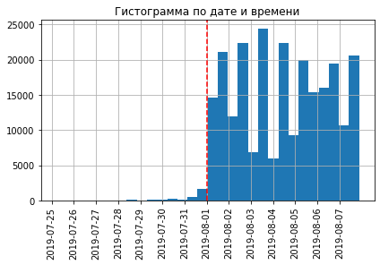

```python
# Расчёт дат для оси X
start = df.date.min()
end = df.date.max()
dates = pd.date_range(start, end, freq='D')

df['event_time'].hist(grid=True, bins=30, xrot=90)
plt.xticks(dates)
plt.tight_layout()
plt.title('Гистограмма по дате и времени')

# Вертикальная линия, чтобы отделить тестовый период
plt.axvline(pd.to_datetime('2019-08-01'), ls='--', color='r')
plt.show()
```

```
У нас не достаточно данных за период с 2019-07-25 по 2019-07-31.
С 2019-08-01 по 2019-08-07 данные полные.
```

```python
# Оставляем полные данные
date_threshold = pd.to_datetime('2019-08-01', format = '%Y-%m-%d')
df_cor_date = df[df['date'] >= date_threshold]
```

```python
df_cor_date['date'].unique()
```

```
array([datetime.date(2019, 8, 1), datetime.date(2019, 8, 2),
       datetime.date(2019, 8, 3), datetime.date(2019, 8, 4),
       datetime.date(2019, 8, 5), datetime.date(2019, 8, 6),
       datetime.date(2019, 8, 7)], dtype=object)
```

**Много ли событий и пользователей вы потеряли, отбросив старые данные?**

```python
filtered_events = len(df_cor_date)
difference = len(df) - len(df_cor_date)
difference2 = difference*100/len(df)
print('Всего событий в отфильтрованной таблице: {}'.format(filtered_events), 'шт.')
print('Всего событий в первоначальной  таблице: {}'.format(events), 'шт.')
print('Разность событий: {}'.format(difference), 'шт. или {:.2f}%'.format(difference2))
```

```
Всего событий в отфильтрованной таблице: 240887 шт.
Всего событий в первоначальной  таблице: 243713 шт.
Разность событий: 2826 шт. или 1.16%
```

```python
filtered_users = df_cor_date['user_id'].nunique()
difference_users = df['user_id'].nunique() - df_cor_date['user_id'].nunique()
difference_users2 = difference_users*100/df['user_id'].nunique()
print('Всего уникальных пользователей в первоначальной  таблице: {}'.format(users), 'чел.')
print('Всего уникальных пользователей в отфильтрованной таблице: {}'.format(filtered_users), 'чел.')
print('Разность пользователей: {}'.format(difference_users), 'или {:.2f}%'.format(difference_users2))
```

```
Всего уникальных пользователей в первоначальной  таблице: 7551 чел.
Всего уникальных пользователей в отфильтрованной таблице: 7534 чел.
Разность пользователей: 17 или 0.23%
```

**Проверьте, что у вас есть пользователи из всех трёх экспериментальных групп**

```python
df_cor_date['group'].value_counts()
```

```
248    84563
246    79302
247    77022
Name: group, dtype: int64
```

## Шаг 4. Анализ воронки событий

**Задача: посмотрите, какие события есть в логах, как часто они встречаются. Отсортируйте события по частоте**

```python
events_count = df_cor_date.groupby('event').agg({'user_id':'count'}).reset_index().sort_values(by='user_id', ascending=False)
events_count.rename(columns={'event': 'name_event', 'user_id': 'quantity_events'}, inplace=True)
events_count
```

|  | name_event | quantity_events |
| --- | --- | --- |
| 1 | MainScreenAppear | 117328 |
| 2 | OffersScreenAppear | 46333 |
| 0 | CartScreenAppear | 42303 |
| 3 | PaymentScreenSuccessful | 33918 |
| 4 | Tutorial | 1005 |

Всего 5 событий, отсортированы по частоте:

- MainScreenAppear - появление главного экрана
- OffersScreenAppear - предложение о товаре (экран с товаром)
- CartScreenAppear - переход в корзину
- PaymentScreenSuccessful - экран успешной оплаты заказа
- Tutorial - прохождение обучения по использоваю приложения (по желанию)

**Задача: посчитайте, сколько пользователей совершали каждое из этих событий. Отсортируйте события по числу пользователей. Посчитайте долю пользователей, которые хоть раз совершали событие**

```python
quantity_unique_users = df_cor_date.groupby('event').agg({'user_id':'nunique'}).reset_index().sort_values(by='user_id', ascending=False)
quantity_unique_users.rename(columns={'event': 'name_event', 'user_id': 'quantity_unique_users'}, inplace=True)
quantity_unique_users
```

|  | name_event | quantity_unique_users |
| --- | --- | --- |
| 1 | MainScreenAppear | 7419 |
| 2 | OffersScreenAppear | 4593 |
| 0 | CartScreenAppear | 3734 |
| 3 | PaymentScreenSuccessful | 3539 |
| 4 | Tutorial | 840 |

```
Мы получили воронку событий. Построим график, но без одного этапа "Tutorial",
так как данный этап малочисленный и необязательный.
```

```python
import plotly.io as pio
png_renderer = pio.renderers["png"]
png_renderer
```

```
PngRenderer(width=700, height=450, scale=None)

    Renderer to display figures as static PNG images.  This renderer requires
    the orca command-line utility and is broadly compatible across IPython
    environments (classic Jupyter Notebook, JupyterLab, QtConsole, VSCode,
    PyCharm, etc) and nbconvert targets (HTML, PDF, etc.).

    mime type: 'image/png'
```

```python
from plotly import graph_objects as go
fig = go.Figure(go.Funnel(
    y = ["MainScreenAppear","OffersScreenAppear", "CartScreenAppear", "PaymentScreenSuccessful"],
    x = [7419, 4593,  3734, 3539]
    ))
fig.show()
```

[interactive chart not shown]

```
Соединим две таблицы, чтобы получить название события, количество событий
и количество событий, которое было совершено уникальными пользователями.
```

```python
event_table = pd.concat([events_count, quantity_unique_users['quantity_unique_users']],axis=1)
event_table
```

|  | name_event | quantity_events | quantity_unique_users |
| --- | --- | --- | --- |
| 1 | MainScreenAppear | 117328 | 7419 |
| 2 | OffersScreenAppear | 46333 | 4593 |
| 0 | CartScreenAppear | 42303 | 3734 |
| 3 | PaymentScreenSuccessful | 33918 | 3539 |
| 4 | Tutorial | 1005 | 840 |

```
Найдем сколько всего уникальных пользователей в датасете,
чтобы определить долю пользователей, которые хоть раз совершали то или иное событие.
```

```python
df_cor_date['user_id'].nunique()
```

```
7534
```

```python
event_table['percent'] = event_table['quantity_unique_users'].apply(lambda x: round(x/7534*100, 1))
event_table
```

|  | name_event | quantity_events | quantity_unique_users | percent |
| --- | --- | --- | --- | --- |
| 1 | MainScreenAppear | 117328 | 7419 | 98.5 |
| 2 | OffersScreenAppear | 46333 | 4593 | 61.0 |
| 0 | CartScreenAppear | 42303 | 3734 | 49.6 |
| 3 | PaymentScreenSuccessful | 33918 | 3539 | 47.0 |
| 4 | Tutorial | 1005 | 840 | 11.1 |

**Задача: предположите, в каком порядке происходят события. Все ли они выстраиваются в последовательную цепочку?**

Предположим, что большинство пользователей идут по следующему пути:

- заходят на главную страницу
- заходят на страницу с предложением о товарах
- добавляют товар в корзину
- оплачивают заказ

```python
df_cor_date_main_event = df_cor_date[df_cor_date['event'] != 'Tutorial']
```

```python
users = df_cor_date_main_event.pivot_table(
        index='user_id',
        columns='event',
        values='event_time',
        aggfunc='min')
users.head()
```

| event user_id | CartScreenAppear | MainScreenAppear | OffersScreenAppear | PaymentScreenSuccessful |
| --- | --- | --- | --- | --- |
| 6888746892508752 | NaT | 2019-08-06 14:06:34 | NaT | NaT |
| 6909561520679493 | 2019-08-06 18:52:58 | 2019-08-06 18:52:54 | 2019-08-06 18:53:04 | 2019-08-06 18:52:58 |
| 6922444491712477 | 2019-08-04 14:19:40 | 2019-08-04 14:19:33 | 2019-08-04 14:19:46 | 2019-08-04 14:19:40 |
| 7435777799948366 | NaT | 2019-08-05 08:06:34 | NaT | NaT |
| 7702139951469979 | 2019-08-02 14:28:45 | 2019-08-01 04:29:54 | 2019-08-01 04:29:56 | 2019-08-02 14:28:45 |

```
Каждая строка таблицы — пользователь.
В столбцах — время первого срабатывания каждого события.
Если события не случалось, в его ячейке — NaN
```

```python
step_1 = ~users['MainScreenAppear'].isna()
step_2 = step_1 & (users['OffersScreenAppear'] > users['MainScreenAppear'])
step_3 = step_2 & (users['CartScreenAppear'] > users['OffersScreenAppear'])
step_4 = step_3 & (users['PaymentScreenSuccessful'] > users['OffersScreenAppear'])
```

```python
n_main_pageview = users[step_1].shape[0]
n_offer_pageview = users[step_2].shape[0]
n_add_to_cart = users[step_3].shape[0]
n_payment = users[step_4].shape[0]
```

```python
print('Посетителей зашли на главную страницу:', n_main_pageview)
print('Посетителей зашли на страницу с предложением о товарах:', n_offer_pageview)
print('Добавили товара в корзину:', n_add_to_cart)
print('Оплатили:', n_payment)
```

```
Посетителей зашли на главную страницу: 7419
Посетителей зашли на страницу с предложением о товарах: 4201
Добавили товара в корзину: 1767
Оплатили: 1665
```

```
Сравните полученную воронку с учётом порядка действий пользователей с простой воронкой.
Она выглядела так:
```

```python
quantity_unique_users
```

|  | name_event | quantity_unique_users |
| --- | --- | --- |
| 1 | MainScreenAppear | 7419 |
| 2 | OffersScreenAppear | 4593 |
| 0 | CartScreenAppear | 3734 |
| 3 | PaymentScreenSuccessful | 3539 |
| 4 | Tutorial | 840 |

- Этап MainScreenAppear - является первым у 98.5% уникальных пользователей.
- Этап OffersScreenAppear - является вторым у 91,47% уникальных пользователей.
- Этап CartScreenAppear - является третьим у 47,32% уникальных пользователей.
- Этап PaymentScreenSuccessful - является четвертым этапом у 47,05 % уникальных пользователей.

**Задача: по воронке событий посчитайте, какая доля пользователей проходит на следующий шаг воронки (от числа пользователей на предыдущем). То есть для последовательности событий A → B → C, посчитайте отношение числа пользователей с событием B к количеству пользователей с событием A.**

```python
funnel_of_events = df_cor_date.groupby('event').agg({'user_id':'nunique'}).reset_index()
funnel_of_events.sort_values(by = 'user_id', ascending=False)
```

|  | event | user_id |
| --- | --- | --- |
| 1 | MainScreenAppear | 7419 |
| 2 | OffersScreenAppear | 4593 |
| 0 | CartScreenAppear | 3734 |
| 3 | PaymentScreenSuccessful | 3539 |
| 4 | Tutorial | 840 |

```python
conversion_step2 = round(4593/7419*100)
conversion_step3 = round(3734/4593*100)
conversion_step4 = round(3539/3734*100)

print('% пользователей перешедших на второй этап: {}'.format(conversion_step2))
print('% пользователей перешедших на третий этап: {}'.format(conversion_step3))
print('% пользователей перешедших на четвертый этап: {}'.format(conversion_step4))
```

```
% пользователей перешедших на второй этап: 62
% пользователей перешедших на третий этап: 81
% пользователей перешедших на четвертый этап: 95
```

```
Больше всего теряется пользователей на втором этапе.
После того как пользователь попадает на главную страницу,
только 62% пользователя переходят на страницу с предложениями о товарах.
47,7% пользователей доходит от первого события до оплаты.
```

## Шаг 5. Анализ результатов эксперимента

**Сколько пользователей в каждой экспериментальной группе?**

```python
users_per_group = df_cor_date.groupby('group')['user_id'].nunique().to_frame()
users_per_group.rename(columns={'user_id': 'users_count'}, inplace=True)
users_per_group.loc['246_247'] = 4997
users_per_group
```

| group | users_count |
| --- | --- |
| 246 | 2484 |
| 247 | 2513 |
| 248 | 2537 |
| 246_247 | 4997 |

**Есть 2 контрольные группы для А/А-эксперимента, чтобы проверить корректность всех механизмов и расчётов. Проверьте, находят ли статистические критерии разницу между выборками 246 и 247**

1. Выберите самое популярное событие.
2. Посчитайте число пользователей, совершивших это событие в каждой из контрольных групп.
3. Посчитайте долю пользователей, совершивших это событие
4. Проверьте, будет ли отличие между группами статистически достоверным.
5. Проделайте то же самое для всех других событий

```
Создадим таблицу, в которой будет посчитано для всех групп число пользователей,
совершивших каждое событие
```

```python
groups = df_cor_date.pivot_table(values='user_id', index='group', columns='event', aggfunc='nunique')
groups
```

| event group | CartScreenAppear | MainScreenAppear | OffersScreenAppear | PaymentScreenSuccessful | Tutorial |
| --- | --- | --- | --- | --- | --- |
| 246 | 1266 | 2450 | 1542 | 1200 | 278 |
| 247 | 1238 | 2476 | 1520 | 1158 | 283 |
| 248 | 1230 | 2493 | 1531 | 1181 | 279 |

```
Добавим число пользователь в каждую  группу
```

```python
groups = pd.concat([groups, users_per_group['users_count']],axis=1)
groups
```

| group | CartScreenAppear | MainScreenAppear | OffersScreenAppear | PaymentScreenSuccessful | Tutorial | users_count |
| --- | --- | --- | --- | --- | --- | --- |
| 246 | 1266.0 | 2450.0 | 1542.0 | 1200.0 | 278.0 | 2484 |
| 247 | 1238.0 | 2476.0 | 1520.0 | 1158.0 | 283.0 | 2513 |
| 248 | 1230.0 | 2493.0 | 1531.0 | 1181.0 | 279.0 | 2537 |
| 246_247 | NaN | NaN | NaN | NaN | NaN | 4997 |

```
Создадим новую строчку, в которой посчитаем результаты для объединённой
контрольной группы (группа 246 и группа 247).
```

```python
new_row = groups.loc[246] + groups.loc[247]
new_row.name = '246_247'
groups = groups.append([new_row])
groups
```

|  | CartScreenAppear | MainScreenAppear | OffersScreenAppear | PaymentScreenSuccessful | Tutorial | users_count |
| --- | --- | --- | --- | --- | --- | --- |
| 246 | 1266.0 | 2450.0 | 1542.0 | 1200.0 | 278.0 | 2484.0 |
| 247 | 1238.0 | 2476.0 | 1520.0 | 1158.0 | 283.0 | 2513.0 |
| 248 | 1230.0 | 2493.0 | 1531.0 | 1181.0 | 279.0 | 2537.0 |
| 246_247 | NaN | NaN | NaN | NaN | NaN | 4997.0 |
| 246_247 | 2504.0 | 4926.0 | 3062.0 | 2358.0 | 561.0 | 4997.0 |

```python
groups = groups[['MainScreenAppear', 'OffersScreenAppear', 'CartScreenAppear', 'PaymentScreenSuccessful', 'Tutorial', 'users_count']]
groups
```

|  | MainScreenAppear | OffersScreenAppear | CartScreenAppear | PaymentScreenSuccessful | Tutorial | users_count |
| --- | --- | --- | --- | --- | --- | --- |
| 246 | 2450.0 | 1542.0 | 1266.0 | 1200.0 | 278.0 | 2484.0 |
| 247 | 2476.0 | 1520.0 | 1238.0 | 1158.0 | 283.0 | 2513.0 |
| 248 | 2493.0 | 1531.0 | 1230.0 | 1181.0 | 279.0 | 2537.0 |
| 246_247 | NaN | NaN | NaN | NaN | NaN | 4997.0 |
| 246_247 | 4926.0 | 3062.0 | 2504.0 | 2358.0 | 561.0 | 4997.0 |

**Задача: посчитайте долю пользователей, совершивших каждое событие во всех группах.**

```python
groups1 = copy.deepcopy(groups)
groups1['percent_MainScreen'] = round(groups1['MainScreenAppear']/groups1['users_count']*100, 2)
groups1['percent_Offers'] = round(groups1['OffersScreenAppear']/groups1['users_count']*100, 2)
groups1['percent_Cart'] = round(groups1['CartScreenAppear']/groups1['users_count']*100, 2)
groups1['percent_Payment'] = round(groups1['PaymentScreenSuccessful']/groups1['users_count']*100, 2)
groups1['percent_Tutorial'] = round(groups1['Tutorial']/groups1['users_count']*100, 2)
groups1
```

|  | MainScreenAppear | OffersScreenAppear | CartScreenAppear | PaymentScreenSuccessful | Tutorial | users_count | percent_MainScreen | percent_Offers | percent_Cart | percent_Payment | percent_Tutorial |
| --- | --- | --- | --- | --- | --- | --- | --- | --- | --- | --- | --- |
| 246 | 2450.0 | 1542.0 | 1266.0 | 1200.0 | 278.0 | 2484.0 | 98.63 | 62.08 | 50.97 | 48.31 | 11.19 |
| 247 | 2476.0 | 1520.0 | 1238.0 | 1158.0 | 283.0 | 2513.0 | 98.53 | 60.49 | 49.26 | 46.08 | 11.26 |
| 248 | 2493.0 | 1531.0 | 1230.0 | 1181.0 | 279.0 | 2537.0 | 98.27 | 60.35 | 48.48 | 46.55 | 11.00 |
| 246_247 | NaN | NaN | NaN | NaN | NaN | 4997.0 | NaN | NaN | NaN | NaN | NaN |
| 246_247 | 4926.0 | 3062.0 | 2504.0 | 2358.0 | 561.0 | 4997.0 | 98.58 | 61.28 | 50.11 | 47.19 | 11.23 |

**Разница в Долях пользователей, совершивших самое популярное события:**

**MainScreenAppear:**

- 246 - (контрольная группа) максимальный показатель 98,63%
- 247 - (контрольная группа), третий показатель, на 0,1% меньше по сравнению с максимумом.
- 248 - (эксперементальная группа), четвертый показатель, меньше на 0,36% по сравнению с максимумом.
- 246_247 - второй показатель, на 0,05 % меньше по сравнению с максимумом.

**Проверим, будет ли отличие между группами статистически достоверным.**

*Нулевая Гипотеза* - статистически значимой разницы между выборками групп нет (пары: 246 и 247, 246 и 248, 247 и 248, объединенная группа и 248).

*Альтернативная гипотеза* - существует статистически значимая разница между выборками групп (пары: 246 и 247, 246 и 248, 247 и 248, объединенная группа и 248)

Решим задачу сравнения пропорций двух генеральных совокупностей по выборкам из них с помощью z-критерия.

```python
users_events_per_group = df_cor_date.pivot_table(values='user_id', index='event', columns='group', aggfunc='nunique')
users_events_per_group['246_247'] = users_events_per_group[246] + users_events_per_group[247]
users_events_per_group
```

| group event | 246 | 247 | 248 | 246_247 |
| --- | --- | --- | --- | --- |
| CartScreenAppear | 1266 | 1238 | 1230 | 2504 |
| MainScreenAppear | 2450 | 2476 | 2493 | 4926 |
| OffersScreenAppear | 1542 | 1520 | 1531 | 3062 |
| PaymentScreenSuccessful | 1200 | 1158 | 1181 | 2358 |
| Tutorial | 278 | 283 | 279 | 561 |

```python
from scipy import stats as st
import numpy as np
import math as mth
from termcolor import colored # раскраска текста
```

```python
# Воспользуемся Z-критерием
def z_test(group1, group2, event, alpha):
    p1_ev = users_events_per_group.loc[event, group1]
    p2_ev = users_events_per_group.loc[event, group2]
    p1_us = users_per_group.loc[group1, 'users_count']
    p2_us = users_per_group.loc[group2, 'users_count']
    p1 = p1_ev / p1_us
    p2 = p2_ev / p2_us
    difference = p1 - p2
    p_combined = (p1_ev + p2_ev) / (p1_us + p2_us)
    z_value = difference / mth.sqrt(p_combined * (1 - p_combined) * (1 / p1_us + 1 / p2_us))
    distr = st.norm(0, 1)
    p_value = (1 - distr.cdf(abs(z_value))) * 2
    print('Проверка для  {} и {}, событие: {}, p-значение: {p_value:.2f}'.format(group1, group2, event, p_value=p_value))
    if (p_value < alpha):
        print(colored('Отвергаем нулевую гипотезу: между долями есть значимая разница', 'green'))
    else:
        print(colored('Не получилось отвергнуть нулевую гипотезу, нет оснований считать доли разными', 'red'))
```

*События в контрольных группах 246 и 247*

```python
for event in users_events_per_group.index:
    z_test(246, 247, event, 0.05)
    print()
```

```
Проверка для  246 и 247, событие: CartScreenAppear, p-значение: 0.23
Не получилось отвергнуть нулевую гипотезу, нет оснований считать доли разными

Проверка для  246 и 247, событие: MainScreenAppear, p-значение: 0.76
Не получилось отвергнуть нулевую гипотезу, нет оснований считать доли разными

Проверка для  246 и 247, событие: OffersScreenAppear, p-значение: 0.25
Не получилось отвергнуть нулевую гипотезу, нет оснований считать доли разными

Проверка для  246 и 247, событие: PaymentScreenSuccessful, p-значение: 0.11
Не получилось отвергнуть нулевую гипотезу, нет оснований считать доли разными

Проверка для  246 и 247, событие: Tutorial, p-значение: 0.94
Не получилось отвергнуть нулевую гипотезу, нет оснований считать доли разными
```

*События в контрольной группе 246 и эксперементальной группе 248*

```python
for event in users_events_per_group.index:
    z_test(246, 248, event, 0.05)
    print()
```

```
Проверка для  246 и 248, событие: CartScreenAppear, p-значение: 0.08
Не получилось отвергнуть нулевую гипотезу, нет оснований считать доли разными

Проверка для  246 и 248, событие: MainScreenAppear, p-значение: 0.29
Не получилось отвергнуть нулевую гипотезу, нет оснований считать доли разными

Проверка для  246 и 248, событие: OffersScreenAppear, p-значение: 0.21
Не получилось отвергнуть нулевую гипотезу, нет оснований считать доли разными

Проверка для  246 и 248, событие: PaymentScreenSuccessful, p-значение: 0.21
Не получилось отвергнуть нулевую гипотезу, нет оснований считать доли разными

Проверка для  246 и 248, событие: Tutorial, p-значение: 0.83
Не получилось отвергнуть нулевую гипотезу, нет оснований считать доли разными
```

*События в контрольной группе 247 и эксперементальной группе 248*

```python
for event in users_events_per_group.index:
    z_test(247, 248, event, 0.05)
    print()
```

```
Проверка для  247 и 248, событие: CartScreenAppear, p-значение: 0.58
Не получилось отвергнуть нулевую гипотезу, нет оснований считать доли разными

Проверка для  247 и 248, событие: MainScreenAppear, p-значение: 0.46
Не получилось отвергнуть нулевую гипотезу, нет оснований считать доли разными

Проверка для  247 и 248, событие: OffersScreenAppear, p-значение: 0.92
Не получилось отвергнуть нулевую гипотезу, нет оснований считать доли разными

Проверка для  247 и 248, событие: PaymentScreenSuccessful, p-значение: 0.74
Не получилось отвергнуть нулевую гипотезу, нет оснований считать доли разными

Проверка для  247 и 248, событие: Tutorial, p-значение: 0.77
Не получилось отвергнуть нулевую гипотезу, нет оснований считать доли разными
```

*События в объединенной контрольной группе (246 + 247) и эксперементальной 248*

```python
for event in users_events_per_group.index:
    z_test('246_247', 248, event, 0.05)
    print()
```

```
Проверка для  246_247 и 248, событие: CartScreenAppear, p-значение: 0.18
Не получилось отвергнуть нулевую гипотезу, нет оснований считать доли разными

Проверка для  246_247 и 248, событие: MainScreenAppear, p-значение: 0.29
Не получилось отвергнуть нулевую гипотезу, нет оснований считать доли разными

Проверка для  246_247 и 248, событие: OffersScreenAppear, p-значение: 0.43
Не получилось отвергнуть нулевую гипотезу, нет оснований считать доли разными

Проверка для  246_247 и 248, событие: PaymentScreenSuccessful, p-значение: 0.60
Не получилось отвергнуть нулевую гипотезу, нет оснований считать доли разными

Проверка для  246_247 и 248, событие: Tutorial, p-значение: 0.76
Не получилось отвергнуть нулевую гипотезу, нет оснований считать доли разными
```

### Шаг 6. Выводы

Статистически значимых различий между двумя контрольными группами 246 и 247 не найдены. Это один из критериев успешности A/A-теста.

Статистически значимых различий между контрольными группами и эксперементальной группой также не найдены - это значит, что гипотеза о том, что изменение шрифта на главной странице как-то повлияет на метрики конверсии, не подтвердилась.

Необходимо учитывать, что эксперемент проводился в течение 1 недели. Этого может быть не достаточно для выявления различий. Рекомендовано оценить минимальную длительность теста при помощи калькулятора длительности А/В теста и при необходимости продолжить тест.

При изменении уровня значимости на 0.1 (alpha = 0.1) только в одном экспиременте были обнаружены статистические различия: *Событие CartScreenAppear (контрольная группа 246 и эксперементальная 248)*

При выборе критического уровня значимости необходимо обращать внимание на объем выборки. При малом объеме выборки более вероятно получить случайный результат, например, получить различие в двух в выборках при их однородности. Следовательно, можно взять большую вероятность ошибки первого рода. При увеличении объема выборки случайные отклонения компенсируют друг друга, и получить значимое различие в выборках при их однородности менее вероятно. Если объем выборки небольшой до 100 единиц, то можно вполне отвергнуть нулевую гипотезу при уровне значимости 0,1. При объеме выборки, измеряемой сотнями – от 100 до 1000, следует понизить уровень значимости хотя бы до 0,05.

В связи с вышеизложенным был оставлен прежний уровень значимости alpha = 0.05

**Воронка продаж**

**Порядок событий**

- 1 Этап MainScreenAppear - является первым у 98.5% уникальных пользователей.
- 2 Этап OffersScreenAppear - является вторым у 91,47% уникальных пользователей.
- 3 Этап CartScreenAppear - является третьим у 47,32% уникальных пользователей.
- 4 Этап PaymentScreenSuccessful - является четвертым этапом у 47,05 % уникальных пользователей.

**Доля пользователей, перешедших на следующий этап**

- % пользователей перешедших на второй этап: 62%
- % пользователей перешедших на третий этап: 81%
- % пользователей перешедших на четвертый этап: 95%

Больше всего теряется пользователей на втором этапе. После того как пользователь попадает на главную страницу, только 62% пользователя переходят на страницу с предложениями о товарах. 47,7% пользователей доходит от первого события до оплаты.